[figure not shown]

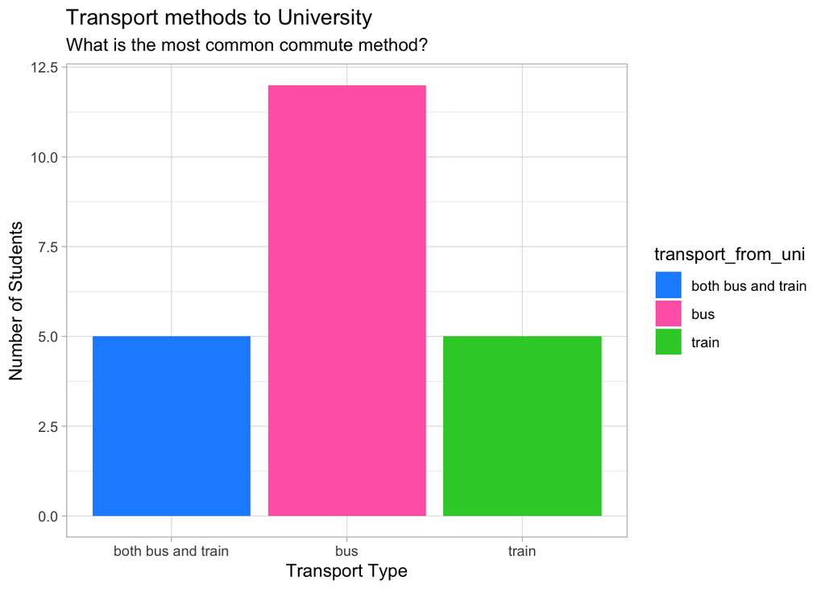

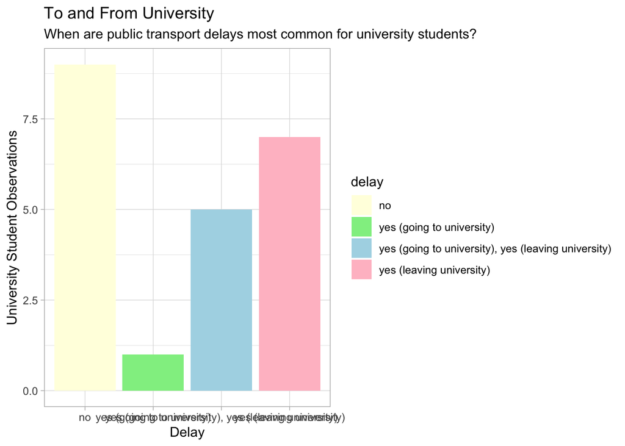

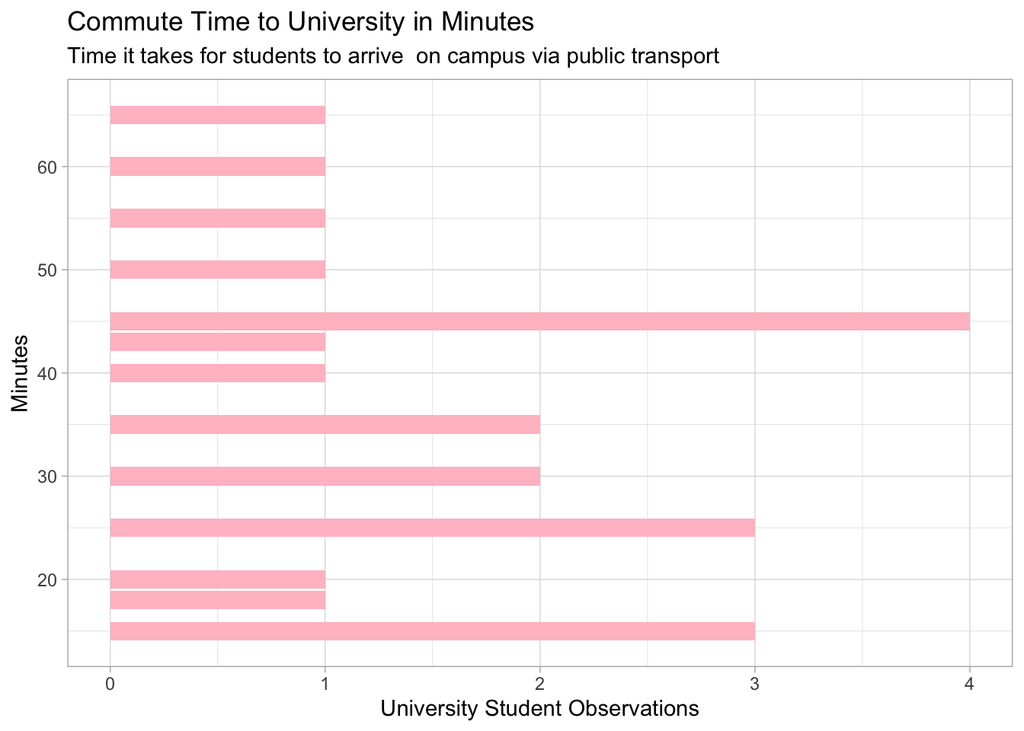

## Dynamic Comments of Summary Statistics

```
## [1] 35.5
```

The mean_commute time to Univeristy in minutes reported by University students who completed the survey was 35.5.

## What is this dynamic report tracking?

This dynamic report is tracking observations of university students’ commutes to and from university who use public transport in Auckland.

## What’s going on with this data?

My dynamic report is tracking the differences in public transport commute methods among university students. I wanted to see if factors like taking the bus or train, commute length, and delays impact how frequently students travel to and from university.

## The nature of your data: What am I analysing?

I am analysing commute and transport habits for university students. I collected this data through a Google Form, which I shared with my friends and also completed myself with my own observations. I designed the form so that each submission reflects a full day of commuting to and from university.